# Data Wrangling and Visualization

Thomas Allen

9/30/2020

```r
within_radius_of_point <- function(df,point,radius) {

  # df : dataframe with RA and Dec columns (Decimal Degrees)

  # point : 2-element vector with center point RA and Dec (Decimal Degrees)

  # radius : radius to search within (Arcseconds)


df <-  df %>%

  mutate(new_column_distance = sqrt( ((point[1] - RA) * 3600. * cos((pi/180.)*Dec))^2   +  ((Dec-point[2]) * 3600.)^2)) %>%
  mutate(new_column = if_else(new_column_distance < radius,"yes", "no"))

df

}
```

```r
df <- read_csv("~/Websites/Working/thomas-s-allen 2/cep_tutorial/data/J.ApJ.750.125.ysos_2MASS_GAIA_raw.csv")
nrow(df)
```

```
## [1] 2569
```

```r
#east_center <- c(344.2083, 62.6656)
east_center <- c(344.2060000, 62.6654278)
west_center <- c(343.4625, 62.5936)

radius <- 300.

df %>% distinct(Note)
```

```
## # A tibble: 2 x 1
##   Note
##   <chr>
## 1 X-ray
## 2 <NA>
```

```r
parallax_conversion <- 10^3 # milli arcseconds to arcseconds

cols_to_keep <- c(
                  "RA",
                  "Dec",
                  "Type",
                  "Band1",
                  "Band2",
                  "Band3",
                  "Band4",
                  "Band5",
                  "Band6",
                  "Band7",
                  "Band8",
                  "Band9",
                  "Band10",
                  "Dust",
                  "Xray",
                  "parallax",
                  "parallax_error",
                  "pmra",
                  "pmra_error",
                  "pmdec",
                  "pmdec_error",
                  "teff_val",
                  "a_g_val",
                  "radius_val",
                  "lum_val"
                  )


df <- df %>%
  mutate(`V-I` = Vmag-`V-I`) %>%
  mutate(Cl = fct_recode(Cl,"No Disk"="III","Disk"="II","Disk"="TD","Envelope"="I")) %>%
  mutate(Note = case_when(Note=="X-ray" ~ "yes",
                            is.na(Note)==TRUE ~ "no")) %>%
  rename(
    RA = `_RAJ2000`,
    Dec = `_DEJ2000`,
    Type = Cl,
    Band1 = Vmag,
    Band2 = `V-I`,
    Band3 = Jmag,
    Band4 = Hmag,
    Band5 = Ksmag,
    Band6 = `[3.6]`,
    Band7 = `[4.5]`,
    Band8 = `[5.8]`,
    Band9 = `[8.0]`,
    Band10 = `[24]`,
    Xray = Note,
    Dust = AKs
  ) %>%
  select(cols_to_keep) %>%
  #filter(Type %in% c("Disk","No Disk")) %>%
  mutate(Distance = 1/ (parallax/parallax_conversion)) %>%
  filter(Distance > 0,
         Distance < 10000) %>%
  within_radius_of_point(east_center,radius) %>%
  mutate(east_cluster = new_column) %>%
  select(-new_column) %>%
  within_radius_of_point(west_center,radius) %>%
  mutate(west_cluster = new_column) %>%
  select(-new_column) %>%
  mutate(Region = if_else(east_cluster=="yes","east",if_else(west_cluster=="yes","west","halo"))) %>%
  select(-new_column_distance,-east_cluster,-west_cluster)

df
```

```
## # A tibble: 2,166 x 27
##       RA   Dec Type   Band1 Band2 Band3 Band4 Band5 Band6 Band7 Band8 Band9
##    <dbl> <dbl> <fct>  <dbl> <dbl> <dbl> <dbl> <dbl> <dbl> <dbl> <dbl> <dbl>
##  1  344.  62.6 No Di…  15.1  13.3  12.1  11.6  11.4  11.2  11.2  11.2  11.2
##  2  344.  62.8 No Di…  17.6  15.2  13.8  13.2  12.9  12.7  12.7  12.6  12.7
##  3  344.  62.7 No Di…  15.9  13.8  12.0  11.2  10.9  10.8  10.8  10.7  10.7
##  4  344.  62.6 No Di…  20.2  17.1  15.0  14.1  13.7  13.4  13.4  13.2  13.3
##  5  344.  62.5 No Di…  18.8  16.1  14.1  13.2  12.9  12.7  12.6  12.6  12.5
##  6  344.  62.4 No Di…  19.6  16.4  14.2  13.3  13.0  12.6  12.6  12.4  11.8
##  7  344.  62.6 No Di…  22.2  18.1  15.8  14.8  14.3  14.0  13.9  14.0  13.9
##  8  344.  62.5 No Di…  19.4  15.9  13.2  12.0  11.6  11.2  11.2  11.1  11.2
##  9  344.  62.4 No Di…  21.2  17.5  14.7  13.5  13.1  12.7  12.7  12.7  12.6
## 10  344.  62.5 No Di…  20.1  16.9  14.6  13.5  13.2  13.0  12.9  12.9  13.0
## # … with 2,156 more rows, and 15 more variables: Band10 <dbl>, Dust <dbl>,
## #   Xray <chr>, parallax <dbl>, parallax_error <dbl>, pmra <dbl>,
## #   pmra_error <dbl>, pmdec <dbl>, pmdec_error <dbl>, teff_val <dbl>,
## #   a_g_val <dbl>, radius_val <dbl>, lum_val <dbl>, Distance <dbl>,
## #   Region <chr>
```

## Problem 1

We are interested in exploring whether the presence (or lack thereof) of a protoplanetary disk around a young star depends on the location of that star in its birth cluster. In this dataset, the `Region` variable gives the location of the stars in the cluster as “east”, “west” and “halo”. And the `Type` variable states disk presence as “Disk”, “No Disk” and “Envelope”. You can either include cases of `Type` “Envelope” with the “Disk” cases or ignore them. For this problem:

### Exploratoru Data Analysis

First, we want to explore our data. Create a useful table and visualization to show the relationship between `Type` and `Region`.

```r
df_counts <- df %>%
 # filter(Xray=="yes",
 #       Type %in% c("Disk","No Disk")) %>%
  filter(Type %in% c("Disk","No Disk")) %>%
         #Subcluster %in% c("east","west")) %>%
  group_by(Region,Type) %>%
  summarize(counts=n()) %>%
  mutate(freq=counts/sum(counts))

df_counts
```

```
## # A tibble: 6 x 4
## # Groups:   Region [3]
##   Region Type    counts  freq
##   <chr>  <fct>    <int> <dbl>
## 1 east   Disk       192 0.444
## 2 east   No Disk    240 0.556
## 3 halo   Disk       507 0.353
## 4 halo   No Disk    929 0.647
## 5 west   Disk       159 0.543
## 6 west   No Disk    134 0.457
```

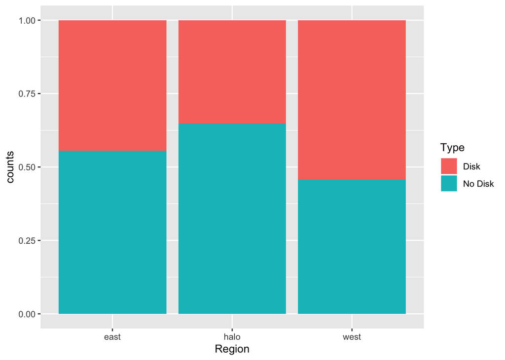

```r
df_counts %>%
  ggplot(aes(x=Region,y=counts,fill=Type)) +
    geom_col(position="fill")
```

### Approximation with probability models

#### Confidence intervals

Now just consider the regions “east” and “west”. For eash region, use an appropriate probability model to estimate the proportion of stars with a protoplanetary disk and determine $95\%$ confidence intervals.

For a single proprtion point estimate:
$$\begin{align}
\hat{p} & \pm MOE \\
\hat{p} & \pm z^{*} \times \sqrt{\frac{\hat{p}(1-\hat{p})}{n}}
\end{align}$$
For the “east” region, since there are 192 stars with a disk and 240 without, $\hat{p} = \frac{192}{192 + 240} = 0.44$:
$$\begin{align}
\hat{p_{east}} & \pm z^{*} \times \sqrt{\frac{\hat{p}(1-\hat{p})}{n}} \\
0.44 & \pm 1.96 \times \sqrt{\frac{0.44(1-0.44)}{432}} \\
0.44 & \pm 0.05
\end{align}$$

```r
1.96 * sqrt( (0.44 * (1 - 0.44)) / 432)
```

```
## [1] 0.04680956
```

And for the “west” region, since there are 159 stars with a disk and 134 without, $\hat{p} = \frac{159}{159 + 134} = 0.54$:
$$\begin{align}
\hat{p_{west}} & \pm z^{*} \times \sqrt{\frac{\hat{p}(1-\hat{p})}{n}} \\
0.54 & \pm 1.96 \times \sqrt{\frac{0.54(1-0.54)}{293}} \\
0.54 & \pm 0.06
\end{align}$$

```r
1.96 * sqrt( (0.54 * (1 - 0.54)) / 293)
```

```
## [1] 0.05706871
```

Therefore, we think that a plausable range of values that contain the popultation porportion in the east region is, $p_{east}$, is $0.39 - 0.49$, and for the west, $p_{west}$, is $0.48 - 0.6$.

#### Hypothesis testing

We want to anser the question, “Do the proportions of stars with disks differ with region?” We will formulate our hypotheses as: $$
$$\begin{align}
H_{0} &: p_{east} - p_{west} = 0 \\
H_{A} &: p_{east} - p_{west} \ne 0
\end{align}$$
$$

We can calculate a $z-score$ test statistic to test this hypothesis:
$$\begin{align}
z & = \frac{\hat{p_{east}} - \hat{p_{west}} - 0}{\sqrt{\frac{\hat{p_{east}}(1-\hat{p_{east}})}{n_{east}} +
\frac{\hat{p_{west}}(1-\hat{p_{west}})}{n_{west}}}} \\
z & = \frac{0.44 - 0.54 - 0}{\sqrt{\frac{0.44(1-0.44)}{432} +
\frac{0.54(1-0.54)}{293}}} \\
z & = -2.66
\end{align}$$

```r
z_score <- (0.44 - 0.54 - 0) / sqrt( (0.44*(1-0.44)/432) + (0.54*(1-0.54)/293))

z_score
```

```
## [1] -2.655453
```

# Color as a function of Type

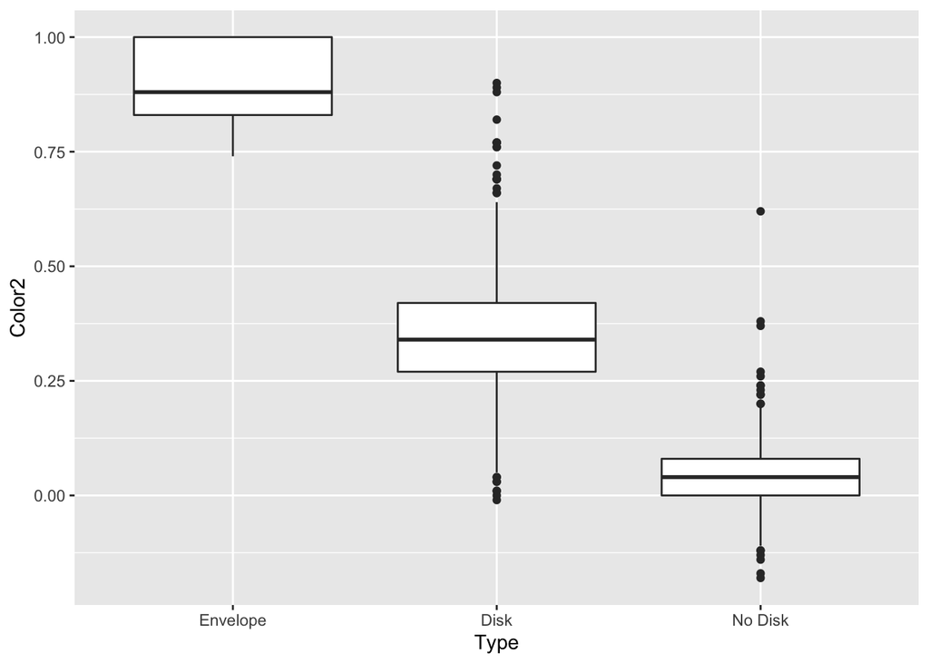

```r
df <- df %>%
  mutate(Color1 = Band3 - Band4,
         Color2 = Band6 - Band7,
         Color3 = Band8 - Band9)


# Boxplot of Index as function of Type (Disk or No Disk)
df %>%
  #drop_na(Band3,Band4,Band5,Band6,Band7,Band8,Band9) %>%
  #mutate(Color1 = Band3-Band4,
  #       Color2 = Band6 - Band7,
  #       Color3 = Band8 - Band9) %>%
  ggplot(aes(x=Type, y=Color2)) +
    geom_boxplot()
```

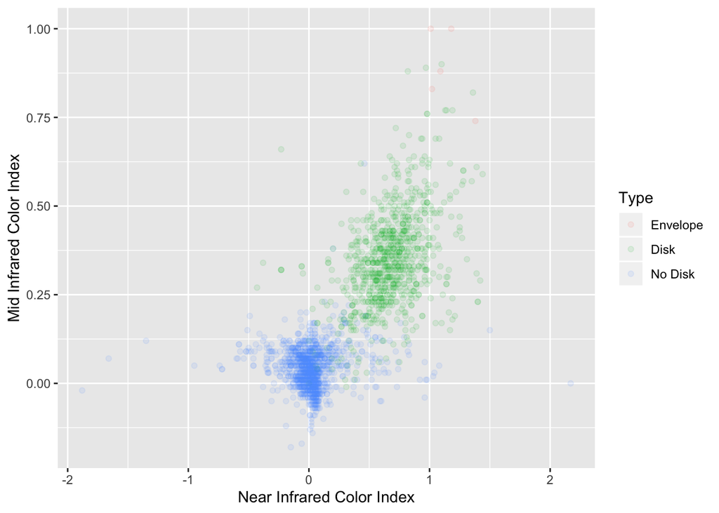

```r
df %>%
  #mutate(Color1 = Band3 - Band4,
  #       Color2 = Band6 - Band7,
  #       Color3 = Band8 - Band9) %>%
  ggplot(aes(x=Color3,y=Color2,color=Type)) +
    geom_point(alpha=0.1) +
    scale_x_continuous(name='Near Infrared Color Index') +
    scale_y_continuous(name="Mid Infrared Color Index")
```

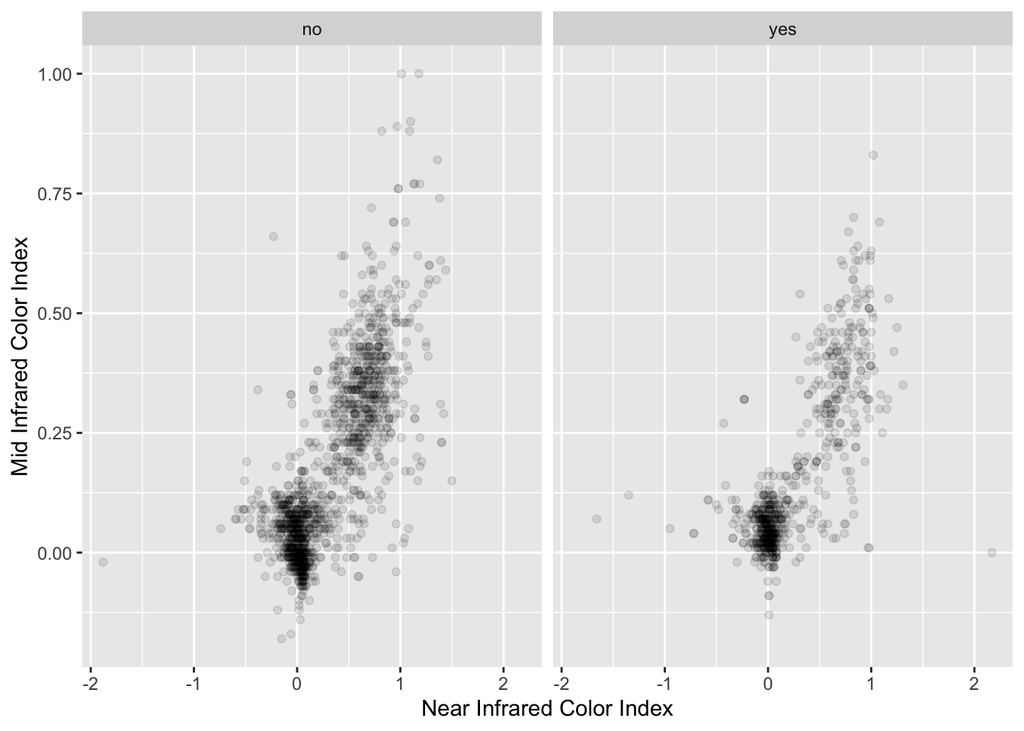

```r
df %>%
  #mutate(Color1 = Band3 - Band4,
  #       Color2 = Band6 - Band7,
  #       Color3 = Band8 - Band9) %>%
  ggplot(aes(x=Color3,y=Color2)) +
    geom_point(alpha=0.1) +
    facet_wrap(~Xray) +
    scale_x_continuous(name='Near Infrared Color Index') +
    scale_y_continuous(name="Mid Infrared Color Index")
```

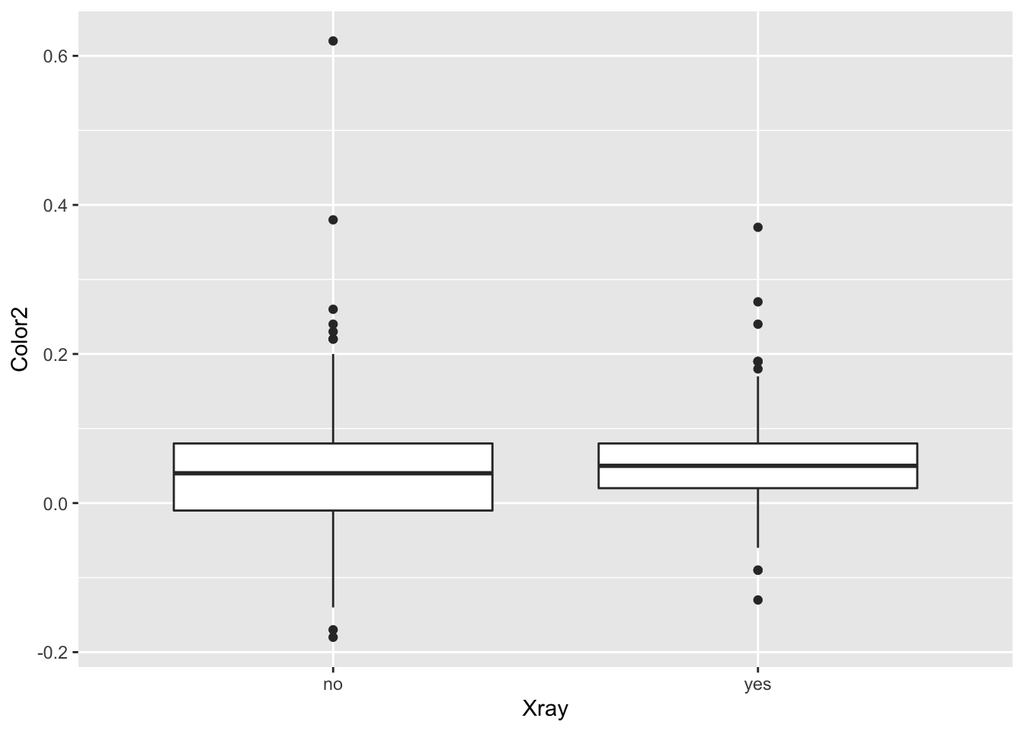

```r
# Boxplor of Color3 for Xray No Xray for No Disks
df %>%
  filter(Type=="No Disk") %>%
  ggplot(aes(x=Xray,y=Color2)) +
  geom_boxplot()
```

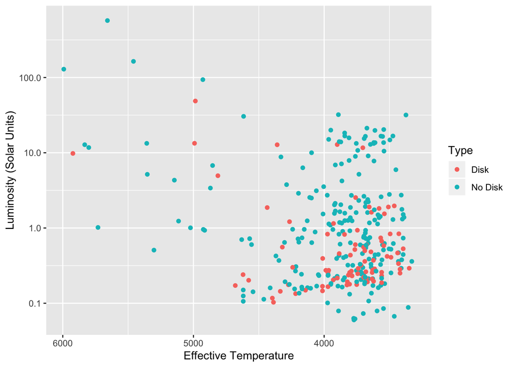

```r
df %>%
  filter(Type %in% c("No Disk","Disk")) %>%
  ggplot(aes(x=teff_val,y=lum_val,color=Type)) +
  geom_point() +
  scale_y_continuous(name="Luminosity (Solar Units)", trans="log10") +
  scale_x_reverse(name="Effective Temperature")
```